# Inleveropdracht5-ML

### Imports

```python
import numpy as np
import tensorflow as tf

from tensorflow import keras
from tensorflow.keras.datasets import cifar10
from tensorflow.keras.models import Sequential
from tensorflow.keras.layers import Dense, Dropout, Activation, Conv2D, MaxPooling2D, Dropout, Flatten, BatchNormalization
from tensorflow.keras.optimizers import Adam
```

## Data-Verkenning

```python
(X_train, y_train), (X_test, y_test) = cifar10.load_data()
```

```
Downloading data from https://www.cs.toronto.edu/~kriz/cifar-10-python.tar.gz
```

**9 voorbeelden van de data**

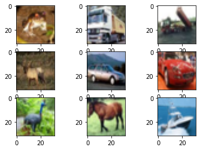

```python
for i in range(9):
    plt.subplot(330 + 1 + i)
    plt.imshow(X_train[i])
plt.show()
```

```python
"""Hoe groot zijn de datasets?"""
print(f'Train-set: Data:{X_train.shape} -- Train:{y_train.shape}')
print(f'Test-set: Data:{X_test.shape} -- Train:{y_test.shape}')
```

```
Train-set: Data:(50000, 32, 32, 3) -- Train:(50000, 1)
Test-set: Data:(10000, 32, 32, 3) -- Train:(10000, 1)
```

Hieruit kunnen de volgende dingen worden opgemaakt:

- Train-set heeft 50k items
- Test-set heeft 10k items
- Elke foto bestaat uit 32x32 = 1024 pixels
- Elke pixel heeft 3 kleurkanalen

Omdat er 10 mogelijke outputs (10 klasses) zijn moeten er dummies worden gemaakt van de target data.

```python
y_train = tf.keras.utils.to_categorical(y_train)
y_test = tf.keras.utils.to_categorical(y_test)

X_train = X_train.astype('float32')
X_test = X_test.astype('float32')
```

## Baseline

Het is logisch om te beginnen met een simpel model en hier mee te spelen. Zo kan ik testen of alles een beetje werkt en weet ik in hoeverre de score nog verbeterd kan/moet worden.

Ik maak hier een simpel model met 3 lagen, en sluit natuurlijk af met een softmax Ik normaliseer de data tussen elke laag, dit zorgt ervoor dat de weights tussen neurons niet extreem hoog/laag word.

### Layer 1: Conv layer

Voor de eerste 2 conv lagen gebruik ik de RELU activatiefunctie. Deze is vaak als beste uit de test gekomen en hebben we het in de laatste lessen ook veel over gehad.

In de eerste laag gebruik ik een filter van 32 (de lengte/breedte van de foto), ik gebruik een standaard kernel_size van 3x3, dit word vaak gedaan.

### Layer 2: Conv layer

Voor laag 2 doe ik bijna hetzelfde. Alleen nu met 4 keer zoveel filters, er zullen andere patronen opgepikt worden.

### Layer 3: Flatten

Hier flatten ik de output. Ik plaats hier bewust 10 neurons omdat er in totaal 10 klassen zijn om te herkennen. De softmax functie bepaald welke output-neuron het qua percentage het meeste geactiveerd is. Deze zal hij uiteindelijk als output pakken & zo een foto classificeren

```python
baseline = Sequential()

baseline.add(Conv2D(activation="relu", filters=32, kernel_size = (3, 3)))
baseline.add(BatchNormalization(axis= -1))

baseline.add(Conv2D(activation="relu", filters=128, kernel_size = (3, 3)))
baseline.add(BatchNormalization(axis= -1))

baseline.add(Flatten())
baseline.add(Dense(10, activation='softmax'))
```

```python
baseline.compile(loss='categorical_crossentropy', metrics=['accuracy'])
```

```python
baseline.summary()
```

```
Model: "sequential_13"
_________________________________________________________________
Layer (type)                 Output Shape              Param #
=================================================================
conv2d_20 (Conv2D)           (None, 30, 30, 32)        896
_________________________________________________________________
batch_normalization_18 (Batc (None, 30, 30, 32)        128
_________________________________________________________________
conv2d_21 (Conv2D)           (None, 28, 28, 128)       36992
_________________________________________________________________
batch_normalization_19 (Batc (None, 28, 28, 128)       512
_________________________________________________________________
flatten_8 (Flatten)          (None, 100352)            0
_________________________________________________________________
dense_8 (Dense)              (None, 10)                1003530
=================================================================
Total params: 1,042,058
Trainable params: 1,041,738
Non-trainable params: 320
_________________________________________________________________
```

```python
baseline_fitted = baseline.fit(X_train, y_train, batch_size=64, epochs=5, validation_split=0.2)
```

```python
loss, accuracy = baseline.evaluate(X_test, y_test)
print(f'Loss: {loss} -- Accuracy: {accuracy}')
```

```
Loss: 1.7329480648040771 -- Accuracy: 0.5715000033378601
```

#### Uitkomsten baseline:

De accuraatheid zit al bijna op de 0.6, ik vind dat een mooie score voor een hele simpele baseline. Maar dit kunnen we natuurlijk nog een heel stuk verbeteren!

## Verbetering

Nu ga ik wat geavanceerdere dingen toevoegen om een betere score te krijgen.

- Extra Conv layer, heb nu 64 filters als tussenlaag toegevoegd, ik hoop dat dit het nauwkeuriger maakt!
- MaxPooling
- Dropout | eerste laag 0.2 andere lagen 0.1 hoger
- Adam optimizer | Veel gebruikte optimizer
- Opnieuw, elke laag Normalisatie. | Zodat weights geen uitschieters worden

Het netwerk eindigd nogsteeds in een Flatten/softmax layer.

```python
final = Sequential()

final.add(Conv2D(activation="relu", filters=32, kernel_size = (3, 3)))
final.add(MaxPooling2D(pool_size=(2,2)))
final.add(BatchNormalization(axis= -1))
final.add(Dropout(0.2))

final.add(Conv2D(activation="relu", filters=64, kernel_size = (3, 3)))
final.add(MaxPooling2D(pool_size=(2,2)))
final.add(BatchNormalization(axis= -1))
final.add(Dropout(0.3))

final.add(Conv2D(activation="relu", filters=182, kernel_size = (3, 3)))
final.add(MaxPooling2D(pool_size=(2,2)))
final.add(BatchNormalization(axis= -1))
final.add(Dropout(0.3))


final.add(Flatten())
final.add(Dense(10, activation='softmax'))
```

```python
final.summary()
```

```
Model: "sequential_15"
_________________________________________________________________
Layer (type)                 Output Shape              Param #
=================================================================
conv2d_25 (Conv2D)           (None, 30, 30, 32)        896
_________________________________________________________________
max_pooling2d_3 (MaxPooling2 (None, 15, 15, 32)        0
_________________________________________________________________
batch_normalization_23 (Batc (None, 15, 15, 32)        128
_________________________________________________________________
dropout_3 (Dropout)          (None, 15, 15, 32)        0
_________________________________________________________________
conv2d_26 (Conv2D)           (None, 13, 13, 64)        18496
_________________________________________________________________
max_pooling2d_4 (MaxPooling2 (None, 6, 6, 64)          0
_________________________________________________________________
batch_normalization_24 (Batc (None, 6, 6, 64)          256
_________________________________________________________________
dropout_4 (Dropout)          (None, 6, 6, 64)          0
_________________________________________________________________
conv2d_27 (Conv2D)           (None, 4, 4, 182)         105014
_________________________________________________________________
max_pooling2d_5 (MaxPooling2 (None, 2, 2, 182)         0
_________________________________________________________________
batch_normalization_25 (Batc (None, 2, 2, 182)         728
_________________________________________________________________
dropout_5 (Dropout)          (None, 2, 2, 182)         0
_________________________________________________________________
flatten_10 (Flatten)         (None, 728)               0
_________________________________________________________________
dense_10 (Dense)             (None, 10)                7290
=================================================================
Total params: 132,808
Trainable params: 132,252
Non-trainable params: 556
_________________________________________________________________
```

```python
final.compile(loss='categorical_crossentropy', metrics=['accuracy'], optimizer = 'adam')
```

```python
final_fitted = final.fit(X_train, y_train, batch_size=128, epochs=20, validation_split=0.2)
```

```python
loss, accuracy = final.evaluate(X_test, y_test)
print(f'Loss: {loss} -- Accuracy: {accuracy}')
```

```
Loss: 0.7064731121063232 -- Accuracy: 0.7646999955177307
```

## Conclusie

De accuracy is erg verbeterd, het toevoegen van de extra laag & features heeft het model erg ten goedde gedaan.

De uiteindelijke score: Loss: 0.706 | Had beter gekund Accuracy: 0.764 | Gaat al richting de 0.8, flinke verbetering ten opzichte van het baseline model